# In-class Exercise 4

A new article created using the Distill format.

FEI JIAHUI https://example.com/norajones (SMU MITB)https://example.com/spacelysprokets  
2022-02-05

# load required packages

```r
packages = c('ggstatsplot', 'ggside',
             'tidyverse', 'ggdist','PMCMRplus')
for (p in packages){
  if(!require(p, character.only = T)){
    install.packages(p)
  }
}
```

# data import

```r
exam <- read_csv("data/Exam_data.csv")
```

# One-sample test: gghistostats() method

In the code chunk below, gghistostats() is used to build an visual of one-sample test on English scores.

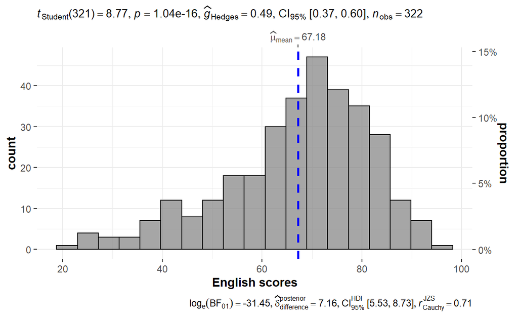

```r
set.seed(1234)
gghistostats(
  data = exam,
  x = ENGLISH,
  type = "p",
  test.value = 60,
  xlab = "English scores"
)
```

# Two-sample mean test: ggbetweenstats()

In the code chunk below, ggbetweenstats() is used to build a visual for two-sample mean test of Maths scores by gender.

```r
ggbetweenstats(
  data = exam,
  x = GENDER,
  y = MATHS,
  type = "p",
  messages = FALSE
)
```

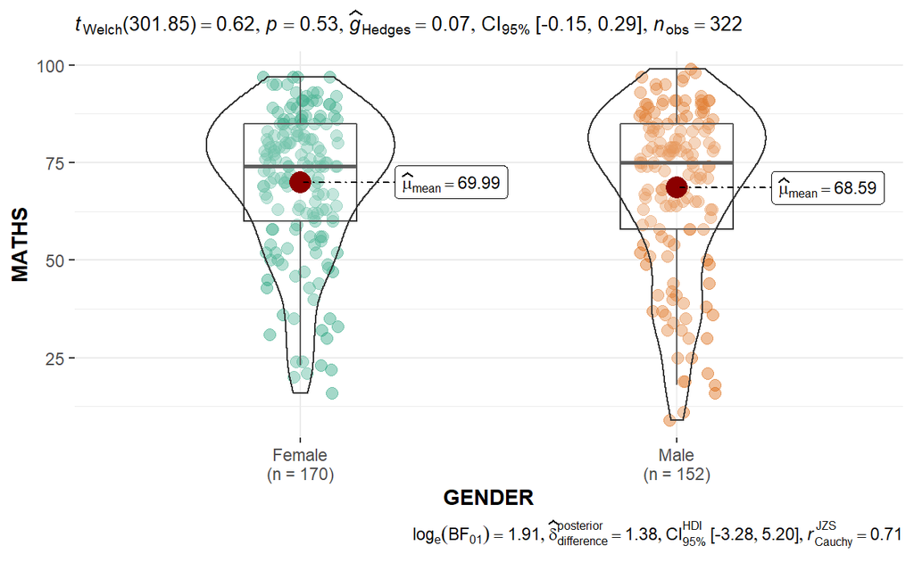

# Oneway ANOVA Test: ggbetweenstats() method

In the code chunk below, ggbetweenstats() is used to build a visual for One-way ANOVA test on English score by race.

```r
ggbetweenstats(
  data = exam,
  x = RACE,
  y = ENGLISH,
  type = "p",
  mean.ci = TRUE,
  pairwise.comparisons = TRUE,
  pairwise.display = "s",
  p.adjust.method = "fdr",
  messages = FALSE
)
```

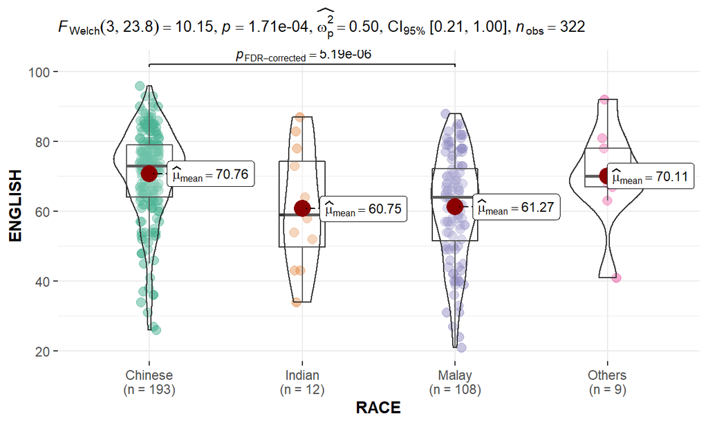

# Significant Test of Correlation: ggscatterstats()

In the code chunk below, ggscatterstats() is used to build a visual for Significant Test of Correlation between Maths scores and English scores.

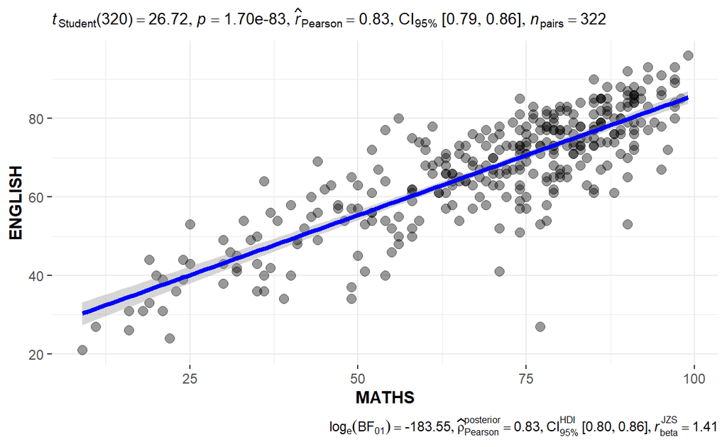

```r
ggscatterstats(
  data = exam,
  x = MATHS,
  y = ENGLISH,
  marginal = FALSE,
  )
```

# Significant Test of Association (Depedence) : ggbarstats() methods

In the code chunk below, the Maths scores is binned into a 4-class variable by using cut().

```r
exam1 <- exam %>%
  mutate(MATHS_bins =
           cut(MATHS,
               breaks = c(0,60,75,85,100))
)
```

In this code chunk below ggbarstats() is used to build a visual for Significant Test of Association

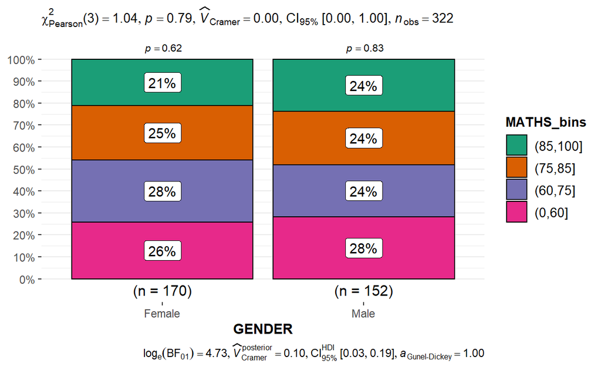

```r
ggbarstats(exam1,
           x = MATHS_bins,
           y = GENDER)
```

# Installing and loading the required libraries

```r
packages = c('readxl', 'report', 'performance',
             'parameters', 'see')
for(p in packages){
  if(!require(p, character.only = T)){
    install.packages(p)
  }
  library(p, character.only = T)
}
```

# Importing Excel file: readxl methods

In the code chunk below, read_xls() of readxl package is used to import the data worksheet of ToyotaCorolla.xls workbook into R.

```r
car_resale <- read_xls("data/ToyotaCorolla.xls",
                       "data")
```

# Multiple Regression Model using lm()

The code chunk below is used to calibrate a multiple linear regression model by using lm() of Base Stats of R.

```r
model <- lm(Price ~ Age_08_04 + Mfg_Year + KM +
              Weight + Guarantee_Period, data = car_resale)
model
```

```
Call:
lm(formula = Price ~ Age_08_04 + Mfg_Year + KM + Weight + Guarantee_Period,
    data = car_resale)

Coefficients:
     (Intercept)         Age_08_04          Mfg_Year
      -2.637e+06        -1.409e+01         1.315e+03
              KM            Weight  Guarantee_Period
      -2.323e-02         1.903e+01         2.770e+01
```

# Model Diagnostic: checking for multicolinearity:

In the code chunk, check_collinearity() of performance package.

```r
check_collinearity(model)
```

```
# Check for Multicollinearity

Low Correlation

             Term  VIF Increased SE Tolerance
               KM 1.46         1.21      0.68
           Weight 1.41         1.19      0.71
 Guarantee_Period 1.04         1.02      0.97

High Correlation

      Term   VIF Increased SE Tolerance
 Age_08_04 31.07         5.57      0.03
  Mfg_Year 31.16         5.58      0.03
```

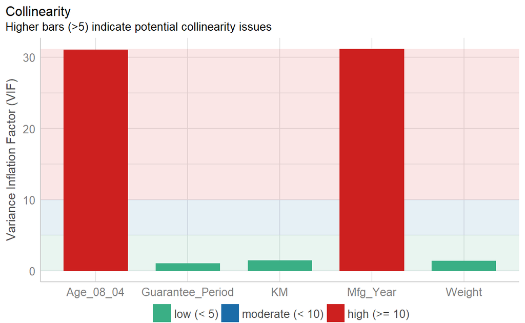

```r
check_c <- check_collinearity(model)
plot(check_c)
```

# Model Diagnostic: checking normality assumption

In the code chunk, check_normality() of performance package.

```r
check_n <- check_normality(model)
```

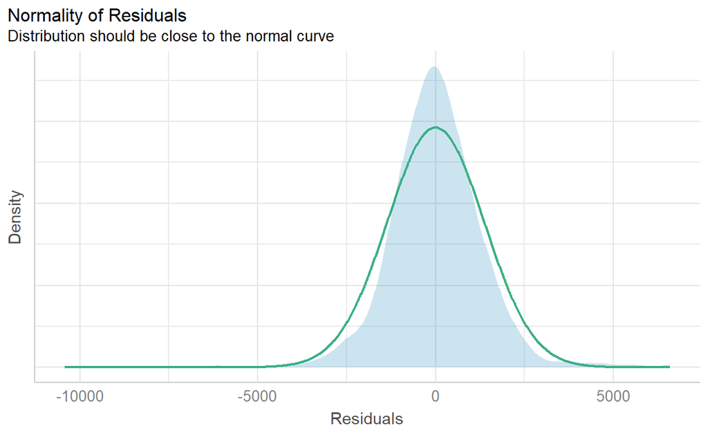

```r
plot(check_n)
```

# Model Diagnostic: Check model for homogeneity of variances

In the code chunk, check_heteroscedasticity() of performance package.

```r
check_h <- check_heteroscedasticity(model)
```

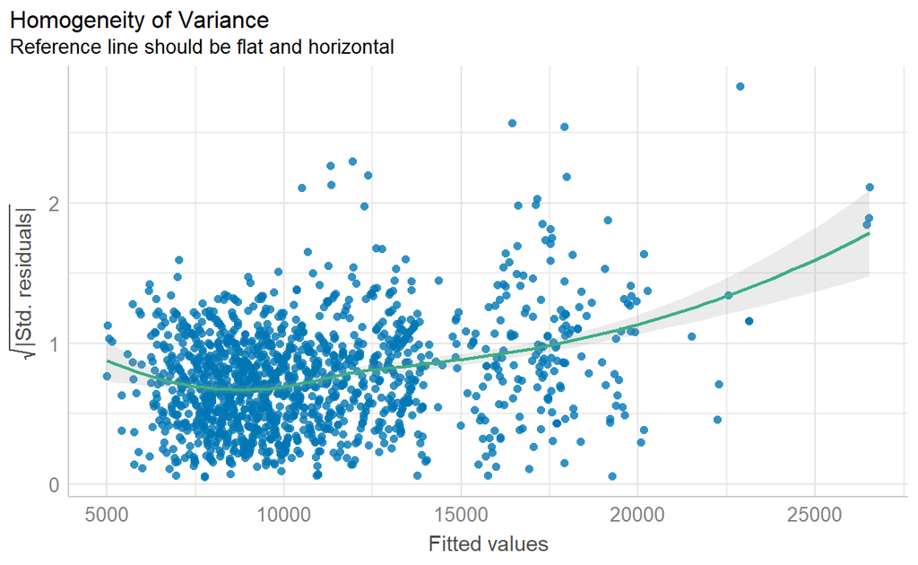

```r
plot(check_h)
```

# Model Diagnostic: Complete check

We can also perform the complete by using check_model().

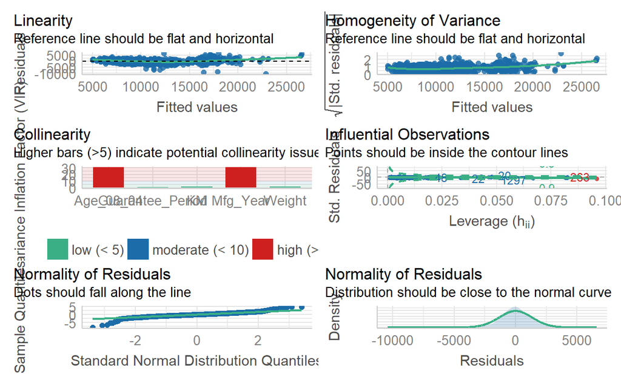

```r
check_model(model)
```

# Visualising Regression Parameters: see methods

In the code below, plot() of see package and parameters() of parameters package is used to visualise the parameters of a regression model.

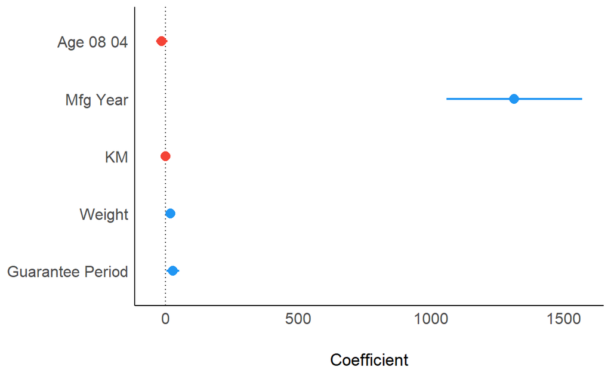

```r
plot(parameters(model))
```

# Visualising Regression Parameters: ggcoefstats() methods

In the code below, ggcoefstats() of ggstatsplot package to visualise the parameters of a regression model.

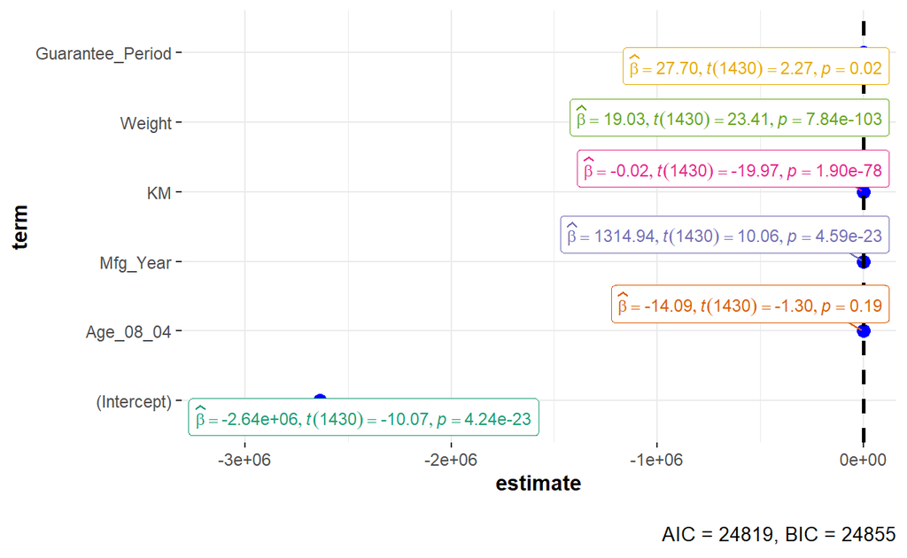

```r
ggcoefstats(model,
            output = "plot")
```

# Visualising uncertainty between groups

In the code chunk below, stat_eye() of ggdist is used to build a visual for displaying distribution of maths scores by rase.

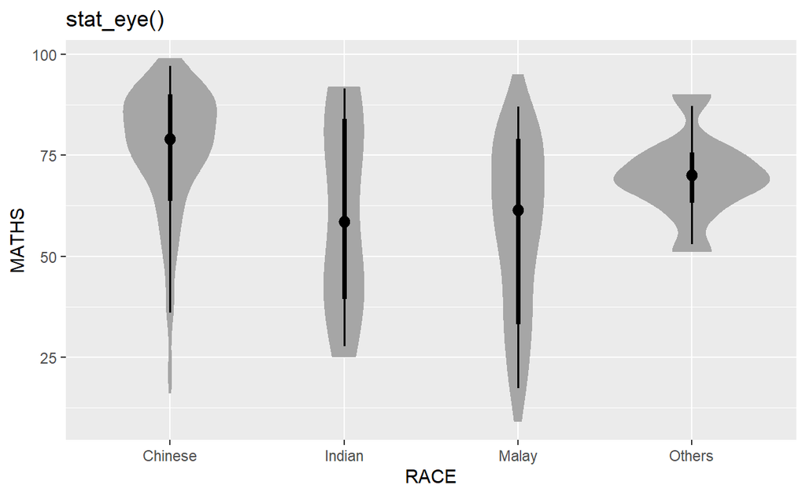

```r
exam %>%
  ggplot(aes(x = RACE, y = MATHS)) +
  stat_eye() +
  ggtitle("stat_eye()")
```